# HUPS3

Chris Harris

Last edited: 30 July, 2020

## Summary

The setup of the experiment was identical to the previous one (HUPS2). This time, however, we had two versions of the DVs in which one time the framing was positive (e.g., “Who of these two would you rather be around in a social setting?”) and the other time the framing was negative (e.g., “Who of these two would you be more likely to avoid in a social setting?”). The order was counterbalanced. Following the initial evidence (see below), participants would either first encounter positively framed DVs or negatively framed DVs and thereafter the alternative.

**Coding:** For now I collapsed over order. I recoded the data so that for DVs with the positive framing we expect higher values (e.g., > 0). For DVs with the negative framing we expect the opposite (thus < 0.

.  
.  
.

*From the previous experiment:*

We had two conditions, one with many smiles one with many frowns.

We counterbalanced whether participants saw two males or two females, which of two pairs (two pairs for each gender) they saw, who was shown left and who was shown right, and finally whether the left or the right person was the person shown more frequently.

The distribution participants encountered was for the smiles condition:

|  | Smiles | Frowns |
| --- | --- | --- |
| Person A | 9 | 3 |
| Person B | 3 | 1 |

For the frowns condition it was

|  | Smiles | Frowns |
| --- | --- | --- |
| Person A | 3 | 9 |
| Person B | 1 | 3 |

After a short introduction (“In this study, we investigate how people form impressions of others. You will encounter two individuals a few times and then we will ask you some questions regarding these two individuals.”), participants encountered the initial evidence, and then answered a number of DVs (the other tabs). The order of the tabs is also the order the DVs were asked. I tried to give an indication of what each DV looked like, but participants either had a binary choice in which they clicked on either of the two images. Or they cound indicate their estimate on a slider with the two images as anchors.

## Likeability

*Who of these two would you rather be around in a social setting?*  
*Who of these two would you be more likely to avoid in a social setting?*

(image left) (image right)

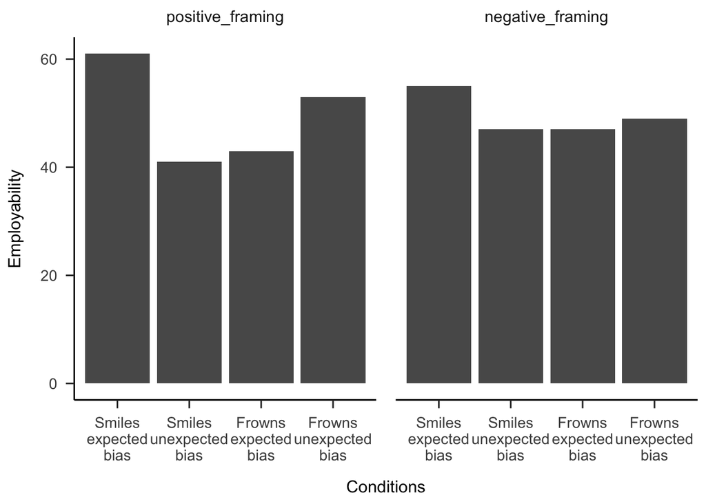

```r
df3 %>%
  mutate(like_cond_pos = case_when(condition == "smiles" & like_pos == 1 ~ "Smiles\nexpected\nbias",
                                   condition == "smiles" & like_pos == -1 ~ "Smiles\nunexpected\nbias",
                                   condition == "frowns" & like_pos == 1 ~ "Frowns\nexpected\nbias",
                                   condition == "frowns" & like_pos == -1 ~ "Frowns\nunexpected\nbias"),
         like_cond_neg = case_when(condition == "smiles" & like_neg == -1 ~ "Smiles\nexpected\nbias",
                                   condition == "smiles" & like_neg == 1 ~ "Smiles\nunexpected\nbias",
                                   condition == "frowns" & like_neg == -1 ~ "Frowns\nexpected\nbias",
                                   condition == "frowns" & like_neg == 1 ~ "Frowns\nunexpected\nbias")) %>%
  pivot_longer(cols = c("like_cond_pos", "like_cond_neg"),
               names_to = "posneg",
               values_to = "like_cond") %>%
  mutate(like_cond = factor(like_cond, levels = c("Smiles\nexpected\nbias",
                                                  "Smiles\nunexpected\nbias",
                                                  "Frowns\nexpected\nbias",
                                                  "Frowns\nunexpected\nbias"))) %>%
  mutate(posneg = factor(posneg, levels = c("like_cond_pos", "like_cond_neg"), labels = c("positive_framing", "negative_framing"))) %>%
  ggplot(aes(x = like_cond)) +
  geom_bar() +
  theme_apa() +
  labs(x = "Conditions",
       y = "Employability") +
  theme(legend.position = "none") +
  facet_wrap(~posneg)
```

## Preference

*Which of these two persons did you like more?*  
*Who of these two did you like less?*

(image left) |———–| (image right)

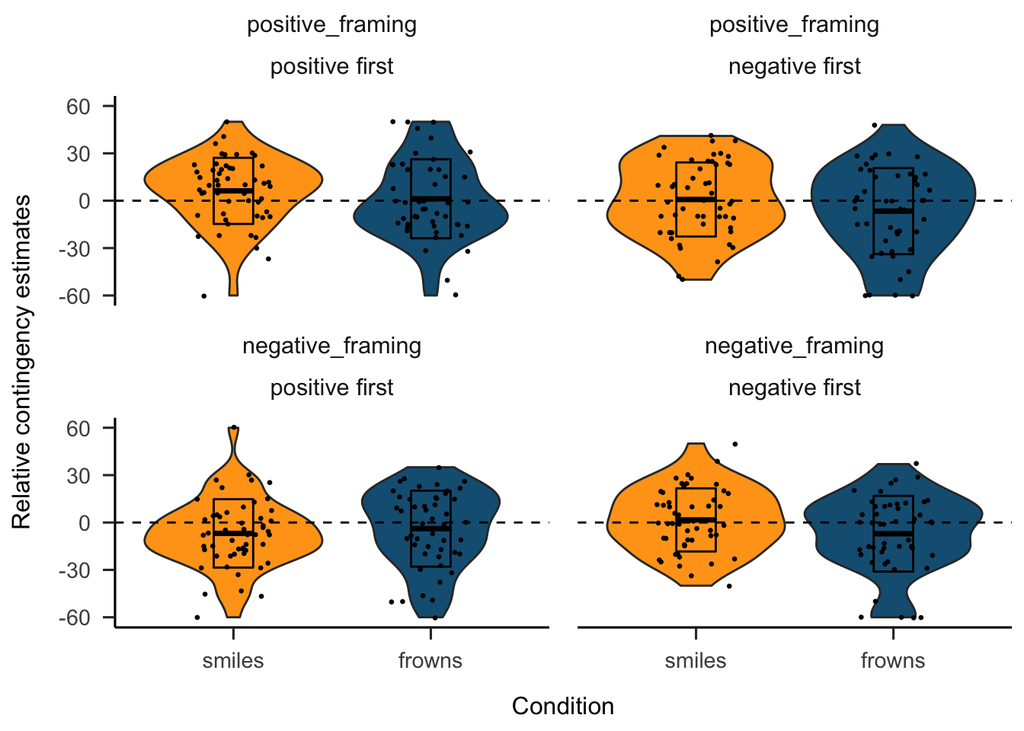

```r
# Graph
df3 %>%
  pivot_longer(cols = c("pref_pos", "pref_neg"),
               names_to = "posneg",
               values_to = "pref") %>%
  mutate(posneg = factor(posneg, levels = c("pref_pos", "pref_neg"), labels = c("positive_framing", "negative_framing"))) %>%
  ggplot(aes(x = condition,
             y = pref,
             fill = condition)) +
  geom_violin() +
  stat_summary(fun.data = "mean_sdl", geom = "crossbar", width = 0.2, fun.args = list(mult = 1)) +
  geom_jitter(size = 0.5, width = 0.2) +
  geom_hline(yintercept = 0, linetype = 2) +
  scale_fill_manual(values = pal) +
  theme_apa() +
  labs(x = "Condition",
       y = "Relative contingency estimates") +
  theme(legend.position = "none") +
  facet_wrap(~posneg + order)
```

```r
### Descriptives
df3 %>%
  pivot_longer(cols = c("pref_pos", "pref_neg"),
               names_to = "posneg",
               values_to = "pref") %>%
  mutate(posneg = factor(posneg, levels = c("pref_pos", "pref_neg"), labels = c("positive_framing", "negative_framing"))) %>%
  group_by(condition, posneg) %>%
  summarize(M = printnum(mean(pref)),
            SD = printnum(sd(pref))) %>%
  knitr::kable(caption = "Descriptives preference", digits = 2) %>%
  kable_styling(bootstrap_options = "hover", full_width = F, position = "center")
```

Descriptives preference

| condition | posneg | M | SD |
| --- | --- | --- | --- |
| smiles | positive_framing | 3.56 | 22.27 |
| smiles | negative_framing | -2.71 | 21.18 |
| frowns | positive_framing | -2.69 | 26.30 |
| frowns | negative_framing | -5.50 | 23.95 |

## Employability

*Who would you rather hire for a job that requires cooperation?*  
*Imagine you are working in a dangerous area and need to hire a personal bodyguard. Who of these two would you rather hire?*

(image left) (image right)

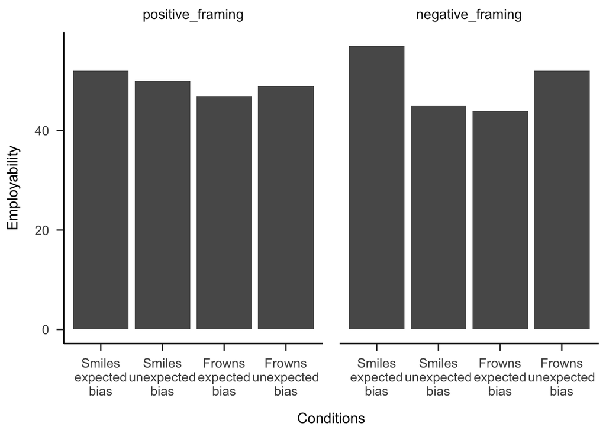

```r
df3 %>%
  mutate(like_empl_pos = case_when(condition == "smiles" & empl_pos == 1 ~ "Smiles\nexpected\nbias",
                                   condition == "smiles" & empl_pos == -1 ~ "Smiles\nunexpected\nbias",
                                   condition == "frowns" & empl_pos == 1 ~ "Frowns\nexpected\nbias",
                                   condition == "frowns" & empl_pos == -1 ~ "Frowns\nunexpected\nbias"),
         like_empl_neg = case_when(condition == "smiles" & empl_neg == -1 ~ "Smiles\nexpected\nbias",
                                   condition == "smiles" & empl_neg == 1 ~ "Smiles\nunexpected\nbias",
                                   condition == "frowns" & empl_neg == -1 ~ "Frowns\nexpected\nbias",
                                   condition == "frowns" & empl_neg == 1 ~ "Frowns\nunexpected\nbias")) %>%
  pivot_longer(cols = c("like_empl_pos", "like_empl_neg"),
               names_to = "posneg",
               values_to = "empl_cond") %>%
  mutate(empl_cond = factor(empl_cond, levels = c("Smiles\nexpected\nbias",
                                                  "Smiles\nunexpected\nbias",
                                                  "Frowns\nexpected\nbias",
                                                  "Frowns\nunexpected\nbias"))) %>%
  mutate(posneg = factor(posneg, levels = c("like_empl_pos", "like_empl_neg"), labels = c("positive_framing", "negative_framing"))) %>%
  ggplot(aes(x = empl_cond)) +
  geom_bar() +
  theme_apa() +
  labs(x = "Conditions",
       y = "Employability") +
  theme(legend.position = "none") +
  facet_wrap(~posneg)
```

## Impression

*On average, did this person seem more grumpy or more cheerful most of the time?*  
*On average, did this person seem more cheerful or more grumpy most of the time?*

Left : Grumpy |———-| Cheerful  
Right: Grumpy |———-| Cheerful  
*reversed for negative DV*

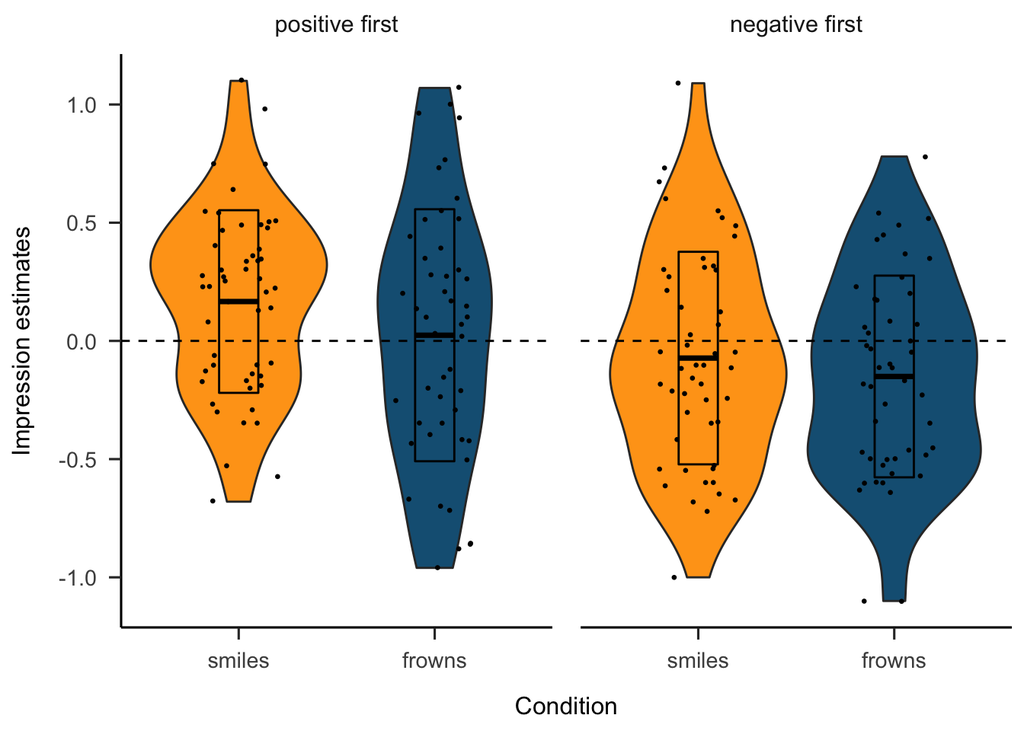

```r
# Graph
df3 %>%
  ggplot(aes(x = condition,
             y = impr_dp,
             fill = condition)) +
  geom_violin() +
  stat_summary(fun.data = "mean_sdl", geom = "crossbar", width = 0.2, fun.args = list(mult = 1)) +
  geom_jitter(size = 0.5, width = 0.2) +
  geom_hline(yintercept = 0, linetype = 2) +
  scale_fill_manual(values = pal) +
  theme_apa() +
  labs(x = "Condition",
       y = "Impression estimates") +
  theme(legend.position = "none") +
  facet_wrap(~order)
```

```r
### Descriptives
df3 %>%
  group_by(condition, order) %>%
  summarize(M = printnum(mean(impr_dp)),
            SD = printnum(sd(impr_dp))) %>%
  knitr::kable(caption = "Descriptives impression", digits = 2) %>%
  kable_styling(bootstrap_options = "hover", full_width = F, position = "center")
```

Descriptives impression

| condition | order | M | SD |
| --- | --- | --- | --- |
| smiles | positive first | 0.17 | 0.39 |
| smiles | negative first | -0.07 | 0.45 |
| frowns | positive first | 0.02 | 0.53 |
| frowns | negative first | -0.15 | 0.43 |

## Conditional estimates

*How likely (in %) was it that if you encountered… ….XXX, they smiled/frowned?*

Left : 0 |———-| 100  
Right: 0 |———-| 100

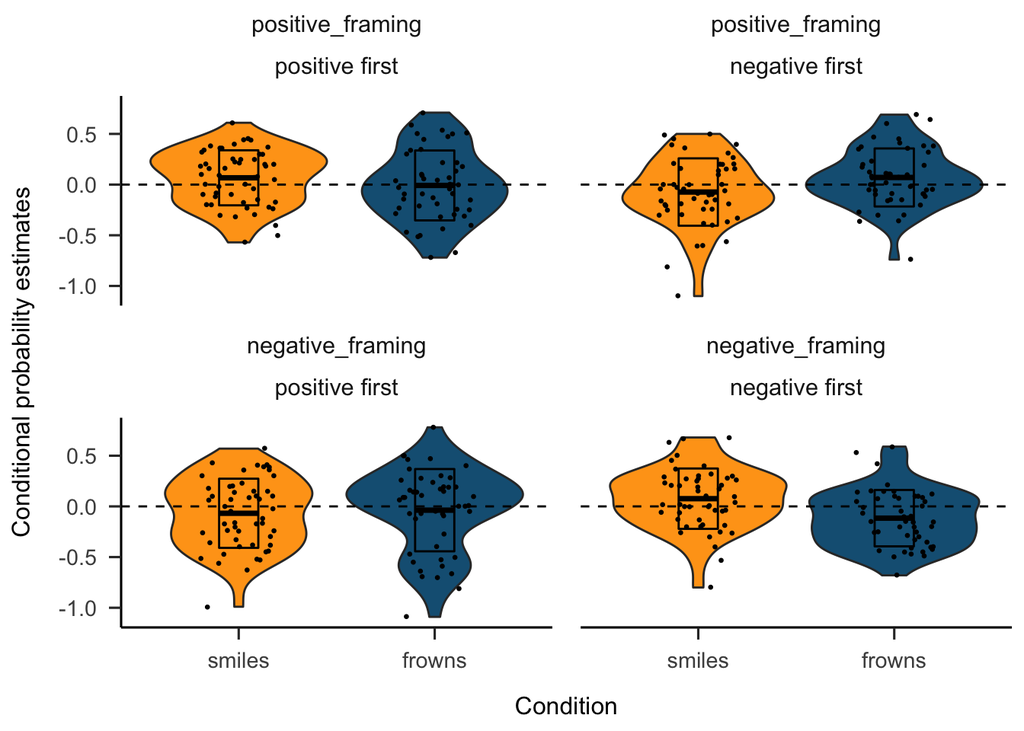

```r
df3 %>%
  pivot_longer(cols = c("cond_pos_dp", "cond_neg_dp"),
               names_to = "posneg",
               values_to = "cond_dp") %>%
  mutate(posneg = factor(posneg, levels = c("cond_pos_dp", "cond_neg_dp"), labels = c("positive_framing", "negative_framing"))) %>%
  ggplot(aes(x = condition,
             y = cond_dp,
             fill = condition)) +
  geom_violin() +
  stat_summary(fun.data = "mean_sdl", geom = "crossbar", width = 0.2, fun.args = list(mult = 1)) +
  geom_jitter(size = 0.5, width = 0.2) +
  geom_hline(yintercept = 0, linetype = 2) +
  scale_fill_manual(values = pal) +
  theme_apa() +
  labs(x = "Condition",
       y = "Conditional probability estimates") +
  theme(legend.position = "none") +
  facet_wrap(~posneg + order)
```

```r
### Descriptives
df3 %>%
  pivot_longer(cols = c("cond_pos_dp", "cond_neg_dp"),
               names_to = "posneg",
               values_to = "cond_dp") %>%
  mutate(posneg = factor(posneg, levels = c("cond_pos_dp", "cond_neg_dp"), labels = c("positive_framing", "negative_framing"))) %>%
  group_by(condition, posneg) %>%
  summarize(M = printnum(mean(cond_dp)),
            SD = printnum(sd(cond_dp))) %>%
  knitr::kable(caption = "Conditional probability estimates", digits = 2) %>%
  kable_styling(bootstrap_options = "hover", full_width = F, position = "center")
```

Conditional probability estimates

| condition | posneg | M | SD |
| --- | --- | --- | --- |
| smiles | positive_framing | 0.00 | 0.31 |
| smiles | negative_framing | 0.00 | 0.33 |
| frowns | positive_framing | 0.03 | 0.32 |
| frowns | negative_framing | -0.08 | 0.35 |

## Confidence

*How confident (in %) are you that you can make a reasonable estimate?*

Left : 0 |———-| 100  
Right: 0 |———-| 100

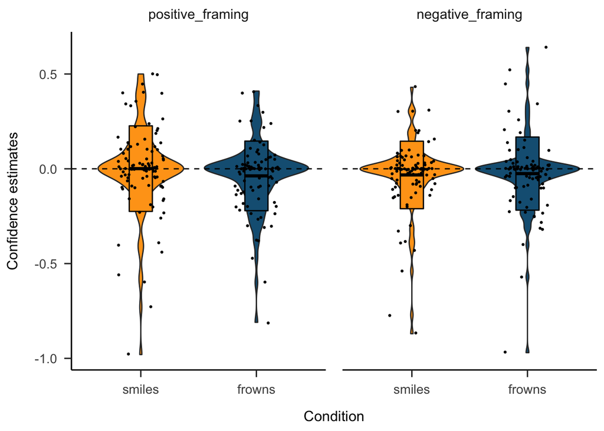

```r
# Graph
df3 %>%
  pivot_longer(cols = c("conf_pos_dp", "conf_neg_dp"),
               names_to = "posneg",
               values_to = "conf_dp") %>%
  mutate(posneg = factor(posneg, levels = c("conf_pos_dp", "conf_neg_dp"), labels = c("positive_framing", "negative_framing"))) %>%
  ggplot(aes(x = condition,
             y = conf_dp,
             fill = condition)) +
  geom_violin() +
  stat_summary(fun.data = "mean_sdl", geom = "crossbar", width = 0.2, fun.args = list(mult = 1)) +
  geom_jitter(size = 0.5, width = 0.2) +
  geom_hline(yintercept = 0, linetype = 2) +
  scale_fill_manual(values = pal) +
  theme_apa() +
  labs(x = "Condition",
       y = "Confidence estimates") +
  theme(legend.position = "none") +
  facet_wrap(~posneg)
```

```r
### Descriptives
df3 %>%
  pivot_longer(cols = c("conf_pos_dp", "conf_neg_dp"),
               names_to = "posneg",
               values_to = "conf_dp") %>%
  group_by(condition, posneg) %>%
  summarize(M = printnum(mean(conf_dp)),
            SD = printnum(sd(conf_dp))) %>%
  knitr::kable(caption = "Confidence estimates", digits = 2) %>%
  kable_styling(bootstrap_options = "hover", full_width = F, position = "center")
```

Confidence estimates

| condition | posneg | M | SD |
| --- | --- | --- | --- |
| smiles | conf_neg_dp | -0.03 | 0.18 |
| smiles | conf_pos_dp | 0.00 | 0.23 |
| frowns | conf_neg_dp | -0.03 | 0.19 |
| frowns | conf_pos_dp | -0.04 | 0.18 |

## Demographic data

Our participants:

```r
# Summary of most relevant demographic data
df3 %>%
  summarise(N = n(),
            female = length(which(gender == "female")),
            age_mean = mean(age, na.rm = TRUE),
            age_sd = sd(age, na.rm = TRUE),
            Psychstudents_percent = length(which(psych == "Yes")) / n() * 100) %>%
  knitr::kable(caption = "Demographic data", digits = 2) %>%
  kable_styling(bootstrap_options = "hover", full_width = F, position = "center")
```

Demographic data

| N | female | age_mean | age_sd | Psychstudents_percent |
| --- | --- | --- | --- | --- |
| 198 | 0 | 29.62 | 8.73 | 8.59 |

And their level of education:

```r
# Level of education
df3 %>%
  group_by(edu) %>%
  summarise(count = length(edu)) %>%
  knitr::kable(caption = "Level of education", digits = 2) %>%
  kable_styling(bootstrap_options = "hover", full_width = F, position = "center")
```

Level of education

| edu | count |
| --- | --- |
| No formal education | 3 |
| Secondary school/GCSE | 31 |
| College/A levels | 48 |
| Undergraduate degree (BA, BSc or comparable) | 62 |
| Graduate degree (MA, MSc or comparable) | 49 |
| Doctorate degree (PhD, MD, or comparable) | 5 |

## Counterbalancing check

This tab is mainly for me to make sure I got the recoding of all the counterbalancing right.

Regression of recoded factors on raw scores:

Preference

```r
# Preference
lm(pref_pos ~ condition, data = df3) %>%
  summary()
```

```
##
## Call:
## lm(formula = pref_pos ~ condition, data = df3)
##
## Residuals:
##     Min      1Q  Median      3Q     Max
## -63.559 -14.312   1.688  18.626  52.688
##
## Coefficients:
##                 Estimate Std. Error t value Pr(>|t|)
## (Intercept)        3.559      2.407   1.479   0.1408
## conditionfrowns   -6.246      3.456  -1.807   0.0723 .
## ---
## Signif. codes:  0 '***' 0.001 '**' 0.01 '*' 0.05 '.' 0.1 ' ' 1
##
## Residual standard error: 24.31 on 196 degrees of freedom
## Multiple R-squared:  0.01639,    Adjusted R-squared:  0.01137
## F-statistic: 3.266 on 1 and 196 DF,  p-value: 0.07227
```

```r
lm(pref1_raw ~ condition * primacy, data = df3_raw) %>%
  summary()
```

```
##
## Call:
## lm(formula = pref1_raw ~ condition * primacy, data = df3_raw)
##
## Residuals:
##    Min     1Q Median     3Q    Max
## -66.06 -15.81   0.96  17.95  54.04
##
## Coefficients:
##                                       Estimate Std. Error t value Pr(>|t|)
## (Intercept)                             49.040      3.428  14.307   <2e-16 ***
## conditionfrowns                         -5.080      4.848  -1.048    0.296
## primacyright frequent                    7.018      4.801   1.462    0.145
## conditionfrowns:primacyright frequent   -1.934      6.897  -0.280    0.779
## ---
## Signif. codes:  0 '***' 0.001 '**' 0.01 '*' 0.05 '.' 0.1 ' ' 1
##
## Residual standard error: 24.24 on 194 degrees of freedom
## Multiple R-squared:  0.03218,    Adjusted R-squared:  0.01721
## F-statistic:  2.15 on 3 and 194 DF,  p-value: 0.09531
```

```r
lm(pref_neg ~ condition, data = df3) %>%
  summary()
```

```
##
## Call:
## lm(formula = pref_neg ~ condition, data = df3)
##
## Residuals:
##     Min      1Q  Median      3Q     Max
## -57.294 -14.294   1.206  16.301  62.706
##
## Coefficients:
##                 Estimate Std. Error t value Pr(>|t|)
## (Intercept)       -2.706      2.234  -1.211    0.227
## conditionfrowns   -2.794      3.209  -0.871    0.385
##
## Residual standard error: 22.56 on 196 degrees of freedom
## Multiple R-squared:  0.003854,   Adjusted R-squared:  -0.001228
## F-statistic: 0.7583 on 1 and 196 DF,  p-value: 0.3849
```

```r
lm(pref2_raw ~ condition * primacy, data = df3_raw) %>%
  summary()
```

```
##
## Call:
## lm(formula = pref2_raw ~ condition * primacy, data = df3_raw)
##
## Residuals:
##     Min      1Q  Median      3Q     Max
## -62.460 -13.660   0.442  16.395  45.413
##
## Coefficients:
##                                       Estimate Std. Error t value Pr(>|t|)
## (Intercept)                             52.460      3.206  16.362   <2e-16 ***
## conditionfrowns                         -8.800      4.534  -1.941   0.0537 .
## primacyright frequent                   -5.402      4.490  -1.203   0.2304
## conditionfrowns:primacyright frequent   16.329      6.451   2.531   0.0122 *
## ---
## Signif. codes:  0 '***' 0.001 '**' 0.01 '*' 0.05 '.' 0.1 ' ' 1
##
## Residual standard error: 22.67 on 194 degrees of freedom
## Multiple R-squared:  0.03519,    Adjusted R-squared:  0.02027
## F-statistic: 2.359 on 3 and 194 DF,  p-value: 0.07293
```

Conditionals

```r
lm(cond_pos_dp ~ condition, data = df3) %>%
  summary()
```

```
##
## Call:
## lm(formula = cond_pos_dp ~ condition, data = df3)
##
## Residuals:
##      Min       1Q   Median       3Q      Max
## -1.09814 -0.19634 -0.00454  0.20936  0.67906
##
## Coefficients:
##                  Estimate Std. Error t value Pr(>|t|)
## (Intercept)     -0.001863   0.031040  -0.060    0.952
## conditionfrowns  0.032800   0.044577   0.736    0.463
##
## Residual standard error: 0.3135 on 196 degrees of freedom
## Multiple R-squared:  0.002755,   Adjusted R-squared:  -0.002333
## F-statistic: 0.5414 on 1 and 196 DF,  p-value: 0.4627
```

```r
lm((cond1_l_raw - cond1_r_raw) ~ condition * primacy, data = df3_raw) %>%
  summary()
```

```
##
## Call:
## lm(formula = (cond1_l_raw - cond1_r_raw) ~ condition * primacy,
##     data = df3_raw)
##
## Residuals:
##      Min       1Q   Median       3Q      Max
## -107.940  -18.905    0.541   21.949   77.200
##
## Coefficients:
##                                       Estimate Std. Error t value Pr(>|t|)
## (Intercept)                            -2.0600     4.4522  -0.463    0.644
## conditionfrowns                        -1.1400     6.2963  -0.181    0.857
## primacyright frequent                   0.4446     6.2355   0.071    0.943
## conditionfrowns:primacyright frequent   5.7336     8.9581   0.640    0.523
##
## Residual standard error: 31.48 on 194 degrees of freedom
## Multiple R-squared:  0.005407,   Adjusted R-squared:  -0.009974
## F-statistic: 0.3515 on 3 and 194 DF,  p-value: 0.7881
```

```r
lm(cond_neg_dp ~ condition, data = df3) %>%
  summary()
```

```
##
## Call:
## lm(formula = cond_neg_dp ~ condition, data = df3)
##
## Residuals:
##      Min       1Q   Median       3Q      Max
## -1.01333 -0.24275  0.02667  0.22667  0.85667
##
## Coefficients:
##                  Estimate Std. Error t value Pr(>|t|)
## (Intercept)      0.002745   0.033426   0.082   0.9346
## conditionfrowns -0.079412   0.048004  -1.654   0.0997 .
## ---
## Signif. codes:  0 '***' 0.001 '**' 0.01 '*' 0.05 '.' 0.1 ' ' 1
##
## Residual standard error: 0.3376 on 196 degrees of freedom
## Multiple R-squared:  0.01377,    Adjusted R-squared:  0.008738
## F-statistic: 2.737 on 1 and 196 DF,  p-value: 0.09967
```

```r
lm((cond2_l_raw - cond2_r_raw) ~ condition * primacy, data = df3_raw) %>%
  summary()
```

```
##
## Call:
## lm(formula = (cond2_l_raw - cond2_r_raw) ~ condition * primacy,
##     data = df3_raw)
##
## Residuals:
##     Min      1Q  Median      3Q     Max
## -97.840 -22.575   1.069  25.295  71.978
##
## Coefficients:
##                                       Estimate Std. Error t value Pr(>|t|)
## (Intercept)                            -1.1600     4.7697  -0.243    0.808
## conditionfrowns                         3.9400     6.7454   0.584    0.560
## primacyright frequent                  -0.4938     6.6802  -0.074    0.941
## conditionfrowns:primacyright frequent -15.2644     9.5970  -1.591    0.113
##
## Residual standard error: 33.73 on 194 degrees of freedom
## Multiple R-squared:  0.02867,    Adjusted R-squared:  0.01365
## F-statistic: 1.909 on 3 and 194 DF,  p-value: 0.1295
```